# Terns body mass analysis

Atlit Common Tern & Little Tern ringing data - issue #5

2026-09-08

# 1 Background

The paper is investigating what drives Little Tern breeding-success collapse at Atlit, alongside the rise in Common Tern numbers. One candidate factor is adult body condition (mass). This report builds and compares three versions of a yearly, per-species mass metric from the raw ringing database (`data_raw/ringing_data_raw.xlsx`, 66k+ individual records, local-only/not in git - see `data_raw/README.md`):

1. **Spring (pre-breeding) mass** - the metric that reproduces Yosef’s original `hirMASS`/`albMASS` columns (issue #5, task 1).
2. **Breeding-season mass** - restricted to June-July and to adults, as a proxy for actual Atlit breeders rather than passage migrants (issue #5, task 2).
3. **Confirmed-breeder spring mass** - a refinement of (1): spring-caught adults restricted further to individuals also encountered in June or July of the *same* year, i.e. more confident they stayed to breed at Atlit rather than just stopping over. Compared statistically against the full spring cohort.

This supersedes `scripts/02_reverse_engineer_mass.R` and `scripts/03_breeding_mass.R`, consolidated here so all three metrics and their comparisons are in one knittable report.

# 2 Data loading

```r
raw_dir <- "../data_raw"
if (!dir.exists(raw_dir)) raw_dir <- "data_raw"
stopifnot(dir.exists(raw_dir))

proc_dir <- "../data_processed"
if (!dir.exists(proc_dir)) proc_dir <- "data_processed"

out_dir <- "../output"
if (!dir.exists(out_dir)) out_dir <- "output"

ringing_path <- file.path(raw_dir, "ringing_data_raw.xlsx")
stopifnot(file.exists(ringing_path))

# The sheet has a 2-row merged header with duplicate leaf names (two "Date"
# columns, two "CR" columns), which readxl's auto name-repair mangles
# unpredictably. Skip both header rows and assign names explicitly, using
# the column mapping verified against data_raw/README.md. The leading "#"
# column (col 1 in the spreadsheet) is entirely empty and readxl drops it
# outright, so the real data is 47 columns, not 48.
col_names_47 <- c(
  "CR1","RingReplace","Rec","RingPrefix","RingNum","Species","Sex","Age","Wing","Weight",
  "Date","Time","Place","Lat","Lon","Ringer","Country","Remarks","Net","CR2","Subsp","Tail","Head",
  "Breeding","CP1","CP2","CP3","CP4","Colour","D","M","OrigDate","OrigCountry","OrigLat","OrigLon","OrigAge",
  "OldCR1","OldCR2","OldCR3","OldMetal1","OldMetal2","OilHead","OilWings","OilUpperP","OilUnderP","OilLegs","OilSum"
)
raw <- read_excel(ringing_path, sheet = "Data", skip = 2, col_names = col_names_47)

# EURING age codes present in this sheet: 1 = pullus (nestling), 3 = this
# calendar year juvenile (this season's fledgling); 4/5/6 and the two-digit
# known-exact-hatch-year codes (14, 22, 25, 28, 29, 35, 37...) are all
# adults (terns can live ~20 years, extending the scale for known-age
# birds - confirmed with Inbal).
juvenile_ages <- c(1, 3)

terns <- raw %>%
  filter(Species %in% c("STEALB", "STEHIR")) %>%
  mutate(
    year = year(Date),
    month = month(Date),
    ring_id = paste0(trimws(RingPrefix), RingNum),
    is_new = is.na(Rec) | trimws(Rec) == "",
    is_adult = !(Age %in% juvenile_ages)
  )

cat("Total tern records:", nrow(terns), "| distinct individuals (ring_id):", n_distinct(terns$ring_id), "\n")
```

```
## Total tern records: 65934 | distinct individuals (ring_id): 18643
```

**Caveat**: `ring_id` (`RingPrefix`+`RingNum`) identifies an individual by its physical ring. 1383 records across the whole sheet are flagged `RingReplace` (ring physically replaced) - for those individuals, matching by `ring_id` across records breaks at the replacement point. Not corrected for here; a source of (probably small) undercount in the matching used in the “confirmed breeder” section below.

# 3 Task 1: Spring (pre-breeding) mass

**Hypothesis** (confirmed in a prior session): `hirMASS`/`albMASS` = mean `Weight` of new (non-recapture) individuals caught in spring (March-May), per species per year.

```r
spring_records <- terns %>%
  filter(is_new, !is.na(Weight), month %in% 3:5)

spring_mass <- spring_records %>%
  group_by(year, Species) %>%
  summarise(mean_weight = mean(Weight), sd_weight = sd(Weight), n = n(), .groups = "drop") %>%
  arrange(Species, year)

kable(spring_mass, digits = 2, caption = "Spring (Mar-May) mean weight, new individuals only, all ages")
```

Spring (Mar-May) mean weight, new individuals only, all ages

| year | Species | mean_weight | sd_weight | n |
| --- | --- | --- | --- | --- |
| 2011 | STEALB | 47.85 | 1.63 | 2 |
| 2012 | STEALB | 47.96 | 7.01 | 9 |
| 2013 | STEALB | 46.23 | 3.65 | 30 |
| 2014 | STEALB | 46.40 | 2.59 | 10 |
| 2015 | STEALB | 46.60 | 2.88 | 5 |
| 2016 | STEALB | 47.48 | 4.66 | 62 |
| 2017 | STEALB | 48.79 | 3.47 | 28 |
| 2018 | STEALB | 46.65 | 2.84 | 51 |
| 2019 | STEALB | 46.57 | 4.93 | 7 |
| 2020 | STEALB | 46.75 | 3.25 | 10 |
| 2021 | STEALB | 45.75 | 3.05 | 12 |
| 2022 | STEALB | 43.95 | 3.14 | 59 |
| 2023 | STEALB | 45.56 | 3.40 | 9 |
| 2024 | STEALB | 49.00 | NA | 1 |
| 2025 | STEALB | 45.33 | 2.16 | 6 |
| 2026 | STEALB | 50.38 | 6.16 | 8 |
| 2011 | STEHIR | 125.80 | 10.59 | 66 |
| 2012 | STEHIR | 129.04 | 11.94 | 166 |
| 2013 | STEHIR | 123.41 | 10.52 | 139 |
| 2014 | STEHIR | 122.38 | 8.65 | 92 |
| 2015 | STEHIR | 121.53 | 9.73 | 163 |
| 2016 | STEHIR | 119.31 | 8.70 | 173 |
| 2017 | STEHIR | 117.02 | 7.11 | 52 |
| 2018 | STEHIR | 121.04 | 9.44 | 130 |
| 2019 | STEHIR | 124.34 | 10.95 | 122 |
| 2020 | STEHIR | 134.95 | 13.19 | 61 |
| 2021 | STEHIR | 117.54 | 8.83 | 181 |
| 2022 | STEHIR | 118.04 | 8.39 | 196 |
| 2023 | STEHIR | 124.71 | 10.19 | 184 |
| 2024 | STEHIR | 122.51 | 13.12 | 35 |
| 2025 | STEHIR | 118.51 | 8.24 | 41 |
| 2026 | STEHIR | 124.67 | 8.75 | 27 |

## 3.1 Validation against the known legacy values (2012-2020)

```r
legacy1 <- read.csv(file.path(raw_dir, "data1_2012-2020_legacy.csv"))
known <- legacy1 %>%
  select(year, hirMASS, albMASS) %>%
  pivot_longer(c(hirMASS, albMASS), names_to = "species_col", values_to = "reported_mass") %>%
  mutate(Species = ifelse(species_col == "hirMASS", "STEHIR", "STEALB"))

validation <- known %>%
  left_join(spring_mass, by = c("year", "Species")) %>%
  mutate(diff = mean_weight - reported_mass) %>%
  arrange(Species, year)

kable(validation %>% select(year, Species, reported_mass, computed = mean_weight, n, diff), digits = 2)
```

| year | Species | reported_mass | computed | n | diff |
| --- | --- | --- | --- | --- | --- |
| 2012 | STEALB | 47.4 | 47.96 | 9 | 0.56 |
| 2013 | STEALB | 46.5 | 46.23 | 30 | -0.27 |
| 2014 | STEALB | 45.8 | 46.40 | 10 | 0.60 |
| 2015 | STEALB | 47.1 | 46.60 | 5 | -0.50 |
| 2016 | STEALB | 47.1 | 47.48 | 62 | 0.38 |
| 2017 | STEALB | 48.5 | 48.79 | 28 | 0.29 |
| 2018 | STEALB | 46.4 | 46.65 | 51 | 0.25 |
| 2019 | STEALB | 46.5 | 46.57 | 7 | 0.07 |
| 2020 | STEALB | 47.0 | 46.75 | 10 | -0.25 |
| 2012 | STEHIR | 129.2 | 129.04 | 166 | -0.16 |
| 2013 | STEHIR | 123.2 | 123.41 | 139 | 0.21 |
| 2014 | STEHIR | 122.0 | 122.38 | 92 | 0.38 |
| 2015 | STEHIR | 121.3 | 121.53 | 163 | 0.23 |
| 2016 | STEHIR | 118.8 | 119.31 | 173 | 0.51 |
| 2017 | STEHIR | 117.5 | 117.02 | 52 | -0.48 |
| 2018 | STEHIR | 120.1 | 121.04 | 130 | 0.94 |
| 2019 | STEHIR | 124.5 | 124.34 | 122 | -0.16 |
| 2020 | STEHIR | 133.0 | 134.95 | 61 | 1.95 |

```r
spring_cor <- cor(validation$reported_mass, validation$mean_weight, use = "complete.obs")
spring_mad <- mean(abs(validation$diff), na.rm = TRUE)
```

Correlation (reported vs. computed): **0.9999**. Mean absolute difference: **0.454 g**. Confirms the spring metric reproduces Yosef’s original values almost exactly.

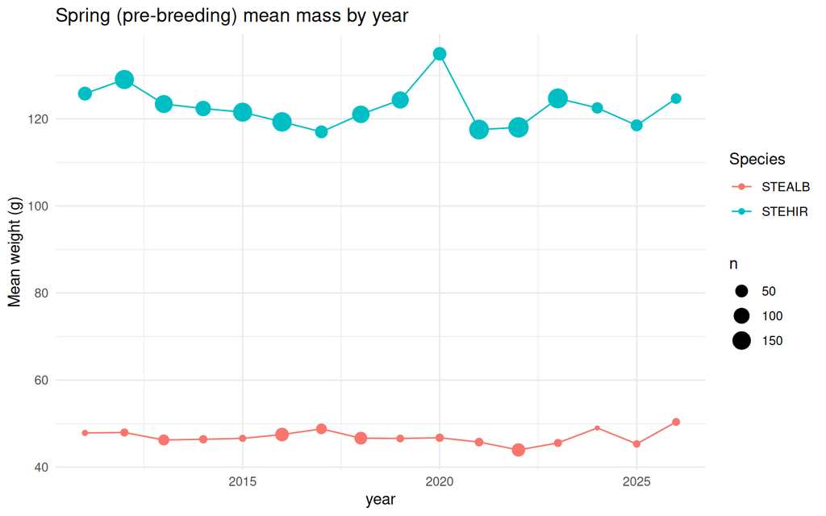

```r
ggplot(spring_mass, aes(year, mean_weight, color = Species)) +
  geom_line() + geom_point(aes(size = n)) +
  labs(title = "Spring (pre-breeding) mean mass by year", y = "Mean weight (g)", size = "n") +
  theme_minimal()
```

# 4 Task 2: Breeding-season (June-July, adults only) mass

```r
age_month_evidence <- terns %>%
  filter(is_new, month %in% 6:7) %>%
  count(Species, month, Age) %>%
  arrange(Species, month, desc(n)) %>%
  group_by(Species, month) %>%
  slice_max(n, n = 3) %>%
  ungroup()

kable(age_month_evidence, caption = "Top age codes by count, new individuals, Jun/Jul (age 1 = pullus, 3 = this-year juvenile - both excluded below)")
```

Top age codes by count, new individuals, Jun/Jul (age 1 = pullus, 3 = this-year juvenile - both excluded below)

| Species | month | Age | n |
| --- | --- | --- | --- |
| STEALB | 6 | 4 | 242 |
| STEALB | 6 | 3 | 154 |
| STEALB | 6 | 1 | 2 |
| STEALB | 7 | 4 | 542 |
| STEALB | 7 | 3 | 499 |
| STEALB | 7 | 5 | 19 |
| STEHIR | 6 | 6 | 988 |
| STEHIR | 6 | 3 | 106 |
| STEHIR | 6 | 5 | 9 |
| STEHIR | 7 | 6 | 1808 |
| STEHIR | 7 | 3 | 1442 |
| STEHIR | 7 | 5 | 19 |

```r
breeding_records <- terns %>%
  filter(is_new, is_adult, !is.na(Weight), month %in% 6:7)

breeding_mass <- breeding_records %>%
  group_by(year, Species) %>%
  summarise(mean_weight = mean(Weight), sd_weight = sd(Weight), n = n(), .groups = "drop") %>%
  arrange(Species, year)

kable(breeding_mass, digits = 2, caption = "Breeding-season (Jun-Jul) mean weight, new ADULT individuals only")
```

Breeding-season (Jun-Jul) mean weight, new ADULT individuals only

| year | Species | mean_weight | sd_weight | n |
| --- | --- | --- | --- | --- |
| 2010 | STEALB | 44.50 | 3.97 | 63 |
| 2011 | STEALB | 44.69 | 5.21 | 21 |
| 2012 | STEALB | 44.59 | 3.65 | 28 |
| 2013 | STEALB | 43.97 | 3.82 | 29 |
| 2014 | STEALB | 43.83 | 3.14 | 52 |
| 2015 | STEALB | 44.74 | 3.29 | 57 |
| 2016 | STEALB | 45.98 | 2.90 | 59 |
| 2017 | STEALB | 45.00 | 2.56 | 38 |
| 2018 | STEALB | 44.50 | 2.94 | 30 |
| 2019 | STEALB | 45.74 | 3.22 | 34 |
| 2020 | STEALB | 44.32 | 3.45 | 53 |
| 2021 | STEALB | 43.57 | 2.31 | 14 |
| 2022 | STEALB | 43.51 | 2.99 | 37 |
| 2023 | STEALB | 44.00 | 3.10 | 12 |
| 2024 | STEALB | 44.00 | 3.09 | 10 |
| 2025 | STEALB | 45.36 | 3.88 | 8 |
| 2026 | STEALB | 46.85 | 5.82 | 20 |
| 2010 | STEHIR | 111.65 | 10.11 | 62 |
| 2011 | STEHIR | 115.04 | 9.10 | 121 |
| 2012 | STEHIR | 114.37 | 9.57 | 76 |
| 2013 | STEHIR | 113.59 | 7.80 | 39 |
| 2014 | STEHIR | 117.62 | 10.09 | 50 |
| 2015 | STEHIR | 117.41 | 8.77 | 41 |
| 2016 | STEHIR | 114.12 | 8.03 | 109 |
| 2017 | STEHIR | 113.92 | 8.76 | 97 |
| 2018 | STEHIR | 118.52 | 11.51 | 27 |
| 2019 | STEHIR | 113.94 | 9.10 | 63 |
| 2020 | STEHIR | 114.63 | 9.45 | 171 |
| 2021 | STEHIR | 114.07 | 7.10 | 55 |
| 2022 | STEHIR | 115.12 | 8.74 | 65 |
| 2023 | STEHIR | 116.47 | 8.74 | 40 |
| 2024 | STEHIR | 114.53 | 8.91 | 38 |
| 2026 | STEHIR | 116.29 | 10.16 | 63 |

## 4.1 Comparison: spring vs. breeding-season mass

```r
spring_vs_breeding <- spring_mass %>%
  rename(spring_mean = mean_weight, spring_n = n) %>%
  select(year, Species, spring_mean, spring_n) %>%
  full_join(
    breeding_mass %>% rename(breeding_mean = mean_weight, breeding_n = n) %>%
      select(year, Species, breeding_mean, breeding_n),
    by = c("year", "Species")
  ) %>%
  mutate(diff = breeding_mean - spring_mean) %>%
  arrange(Species, year)

kable(spring_vs_breeding, digits = 2)
```

| year | Species | spring_mean | spring_n | breeding_mean | breeding_n | diff |
| --- | --- | --- | --- | --- | --- | --- |
| 2010 | STEALB | NA | NA | 44.50 | 63 | NA |
| 2011 | STEALB | 47.85 | 2 | 44.69 | 21 | -3.16 |
| 2012 | STEALB | 47.96 | 9 | 44.59 | 28 | -3.37 |
| 2013 | STEALB | 46.23 | 30 | 43.97 | 29 | -2.27 |
| 2014 | STEALB | 46.40 | 10 | 43.83 | 52 | -2.57 |
| 2015 | STEALB | 46.60 | 5 | 44.74 | 57 | -1.86 |
| 2016 | STEALB | 47.48 | 62 | 45.98 | 59 | -1.50 |
| 2017 | STEALB | 48.79 | 28 | 45.00 | 38 | -3.79 |
| 2018 | STEALB | 46.65 | 51 | 44.50 | 30 | -2.15 |
| 2019 | STEALB | 46.57 | 7 | 45.74 | 34 | -0.84 |
| 2020 | STEALB | 46.75 | 10 | 44.32 | 53 | -2.43 |
| 2021 | STEALB | 45.75 | 12 | 43.57 | 14 | -2.18 |
| 2022 | STEALB | 43.95 | 59 | 43.51 | 37 | -0.44 |
| 2023 | STEALB | 45.56 | 9 | 44.00 | 12 | -1.56 |
| 2024 | STEALB | 49.00 | 1 | 44.00 | 10 | -5.00 |
| 2025 | STEALB | 45.33 | 6 | 45.36 | 8 | 0.03 |
| 2026 | STEALB | 50.38 | 8 | 46.85 | 20 | -3.52 |
| 2010 | STEHIR | NA | NA | 111.65 | 62 | NA |
| 2011 | STEHIR | 125.80 | 66 | 115.04 | 121 | -10.76 |
| 2012 | STEHIR | 129.04 | 166 | 114.37 | 76 | -14.67 |
| 2013 | STEHIR | 123.41 | 139 | 113.59 | 39 | -9.82 |
| 2014 | STEHIR | 122.38 | 92 | 117.62 | 50 | -4.76 |
| 2015 | STEHIR | 121.53 | 163 | 117.41 | 41 | -4.12 |
| 2016 | STEHIR | 119.31 | 173 | 114.12 | 109 | -5.19 |
| 2017 | STEHIR | 117.02 | 52 | 113.92 | 97 | -3.10 |
| 2018 | STEHIR | 121.04 | 130 | 118.52 | 27 | -2.52 |
| 2019 | STEHIR | 124.34 | 122 | 113.94 | 63 | -10.41 |
| 2020 | STEHIR | 134.95 | 61 | 114.63 | 171 | -20.32 |
| 2021 | STEHIR | 117.54 | 181 | 114.07 | 55 | -3.47 |
| 2022 | STEHIR | 118.04 | 196 | 115.12 | 65 | -2.92 |
| 2023 | STEHIR | 124.71 | 184 | 116.47 | 40 | -8.23 |
| 2024 | STEHIR | 122.51 | 35 | 114.53 | 38 | -7.99 |
| 2025 | STEHIR | 118.51 | 41 | NA | NA | NA |
| 2026 | STEHIR | 124.67 | 27 | 116.29 | 63 | -8.38 |

### 4.1.1 Year-level pattern

```r
for (sp in c("STEHIR", "STEALB")) {
  sub <- spring_vs_breeding %>% filter(Species == sp, !is.na(spring_mean), !is.na(breeding_mean))
  r <- cor(sub$spring_mean, sub$breeding_mean)
  cat("**", sp, "**: correlation (spring vs. breeding) = ", round(r, 3),
      ", mean difference (breeding - spring) = ", round(mean(sub$diff), 2), " g\n\n", sep = "")
}
```

**STEHIR**: correlation (spring vs. breeding) = -0.034, mean difference (breeding - spring) = -7.78 g

**STEALB**: correlation (spring vs. breeding) = 0.569, mean difference (breeding - spring) = -2.29 g

### 4.1.2 Significance test (individual-level)

The year-level correlation/difference above summarises the *pattern* across years, but doesn’t test whether spring and breeding-season weights actually differ. `spring_records` and `breeding_records` are built from disjoint ringing events (a bird’s first-ever ringing record can only be “new” once - see `is_new` in the Data loading section), so these are independent samples of individuals, suitable for a two-sample test:

```r
for (sp in c("STEHIR", "STEALB")) {
  spring_w <- spring_records %>% filter(Species == sp) %>% pull(Weight)
  breeding_w <- breeding_records %>% filter(Species == sp) %>% pull(Weight)
  tt <- t.test(spring_w, breeding_w)
  wt <- wilcox.test(spring_w, breeding_w)
  cat("**", sp, "**: spring n=", length(spring_w), ", mean=", round(mean(spring_w), 2),
      "g; breeding n=", length(breeding_w), ", mean=", round(mean(breeding_w), 2),
      "g; Welch t-test p=", signif(tt$p.value, 3),
      ", Wilcoxon p=", signif(wt$p.value, 3), "\n\n", sep = "")
}
```

**STEHIR**: spring n=1828, mean=122.36g; breeding n=1117, mean=114.79g; Welch t-test p=5.2e-86, Wilcoxon p=2.44e-77

**STEALB**: spring n=309, mean=46.5g; breeding n=565, mean=44.68g; Welch t-test p=5.69e-11, Wilcoxon p=3.59e-12

**Year-controlled robustness check** - as in task 2b, a pooled comparison across years can be confounded if spring/breeding records happen to cluster in different years. This model holds year fixed while estimating the breeding-vs-spring effect:

```r
for (sp in c("STEHIR", "STEALB")) {
  d <- bind_rows(
    spring_records %>% filter(Species == sp) %>% mutate(period = "spring"),
    breeding_records %>% filter(Species == sp) %>% mutate(period = "breeding")
  ) %>%
    mutate(year = factor(year), period = factor(period, levels = c("spring", "breeding")))
  m <- lm(Weight ~ period + year, data = d)
  co <- summary(m)$coefficients
  row <- co[grepl("^period", rownames(co)), , drop = FALSE]
  cat("**", sp, "** (year-controlled): breeding-vs-spring effect = ",
      round(row[1, "Estimate"], 2), " g (SE ", round(row[1, "Std. Error"], 2),
      "), p = ", signif(row[1, "Pr(>|t|)"], 3), "\n\n", sep = "")
}
```

**STEHIR** (year-controlled): breeding-vs-spring effect = -8.08 g (SE 0.42), p = 3.71e-79

**STEALB** (year-controlled): breeding-vs-spring effect = -2 g (SE 0.28), p = 3.62e-12

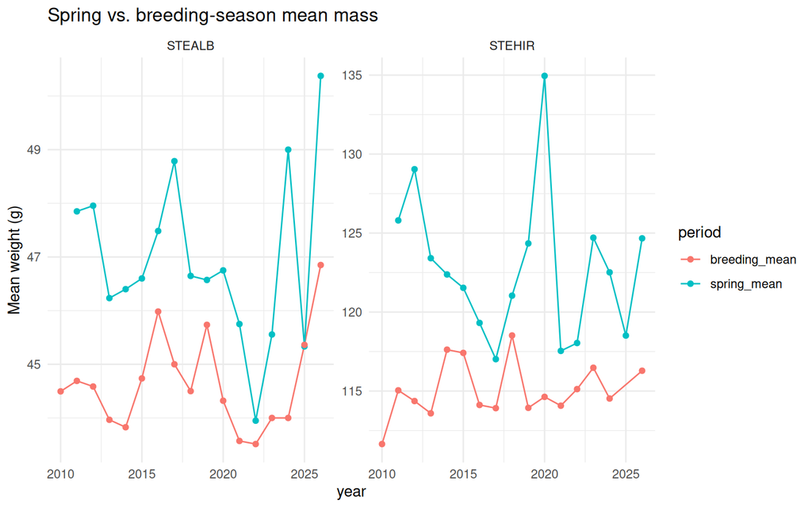

```r
spring_vs_breeding %>%
  select(year, Species, spring_mean, breeding_mean) %>%
  pivot_longer(c(spring_mean, breeding_mean), names_to = "period", values_to = "mean_weight") %>%
  filter(!is.na(mean_weight)) %>%
  ggplot(aes(year, mean_weight, color = period)) +
  geom_line() + geom_point() +
  facet_wrap(~Species, scales = "free_y") +
  labs(title = "Spring vs. breeding-season mean mass", y = "Mean weight (g)") +
  theme_minimal()
```

# 5 Task 2b: Confirmed-breeder spring mass

**Kept for reference/transparency - task 2c (any-year, below) is the chosen definition for downstream analysis as of 2026-09-08.**

**Goal**: check whether Yosef’s original spring mass parameter (task 1 - mean weight of **all** spring-caught adults, new ringings only) differs from the weight of the subset we’re more confident actually bred at Atlit that year. Approach: take **any** adult weighed in spring - a new ringing *or* an in-hand recapture, doesn’t matter which, just that it was caught and weighed in March-May - and flag it as a confirmed breeder if that same ring was also recorded (recapture *or* field resighting, weighed or not) in June or July of the **same year**.

This deliberately does NOT filter to `is_new` (unlike task 1’s spring metric) - a recaptured adult weighed again in spring is just as valid a spring-weight data point as a newly-ringed one for this comparison.

```r
summer_presence <- terns %>%
  filter(month %in% 6:7) %>%
  distinct(ring_id, year) %>%
  mutate(seen_summer = TRUE)

spring_adults <- terns %>%
  filter(is_adult, !is.na(Weight), month %in% 3:5) %>%
  left_join(summer_presence, by = c("ring_id", "year")) %>%
  mutate(confirmed_breeder = coalesce(seen_summer, FALSE))

kable(spring_adults %>% count(Species, confirmed_breeder),
      caption = "Spring adults (new + recaptures): confirmed (seen again Jun/Jul same year) vs. not")
```

Spring adults (new + recaptures): confirmed (seen again Jun/Jul same year) vs. not

| Species | confirmed_breeder | n |
| --- | --- | --- |
| STEALB | FALSE | 322 |
| STEALB | TRUE | 86 |
| STEHIR | FALSE | 1903 |
| STEHIR | TRUE | 180 |

```r
kable(spring_adults %>% count(Species, confirmed_breeder, is_new) %>%
        mutate(is_new = ifelse(is_new, "new ringing", "recapture")),
      caption = "Same breakdown, split by whether the spring record itself was a new ringing or a recapture")
```

Same breakdown, split by whether the spring record itself was a new ringing or a recapture

| Species | confirmed_breeder | is_new | n |
| --- | --- | --- | --- |
| STEALB | FALSE | recapture | 53 |
| STEALB | FALSE | new ringing | 269 |
| STEALB | TRUE | recapture | 46 |
| STEALB | TRUE | new ringing | 40 |
| STEHIR | FALSE | recapture | 188 |
| STEHIR | FALSE | new ringing | 1715 |
| STEHIR | TRUE | recapture | 67 |
| STEHIR | TRUE | new ringing | 113 |

**Caveat**: since recaptures are now included, the same individual can appear more than once in `spring_adults` if it was caught and weighed in spring in more than one year - a mild violation of independence in the pooled tests below (not corrected for, on top of the existing `RingReplace` caveat noted in Data loading).

```r
confirmed_summary <- spring_adults %>%
  group_by(Species, confirmed_breeder) %>%
  summarise(mean_weight = mean(Weight), sd_weight = sd(Weight), n = n(), .groups = "drop")

kable(confirmed_summary, digits = 2, caption = "Spring weight: confirmed breeders vs. unconfirmed spring adults")
```

Spring weight: confirmed breeders vs. unconfirmed spring adults

| Species | confirmed_breeder | mean_weight | sd_weight | n |
| --- | --- | --- | --- | --- |
| STEALB | FALSE | 46.24 | 3.77 | 322 |
| STEALB | TRUE | 46.77 | 4.53 | 86 |
| STEHIR | FALSE | 122.53 | 10.88 | 1903 |
| STEHIR | TRUE | 117.13 | 8.96 | 180 |

```r
confirmed_by_year <- spring_adults %>%
  group_by(year, Species, confirmed_breeder) %>%
  summarise(mean_weight = mean(Weight), n = n(), .groups = "drop")

kable(confirmed_by_year, digits = 2)
```

| year | Species | confirmed_breeder | mean_weight | n |
| --- | --- | --- | --- | --- |
| 2011 | STEALB | FALSE | 46.17 | 3 |
| 2011 | STEALB | TRUE | 43.90 | 1 |
| 2011 | STEHIR | FALSE | 125.80 | 66 |
| 2012 | STEALB | FALSE | 47.44 | 10 |
| 2012 | STEHIR | FALSE | 129.36 | 165 |
| 2012 | STEHIR | TRUE | 121.92 | 4 |
| 2013 | STEALB | FALSE | 46.45 | 31 |
| 2013 | STEHIR | FALSE | 123.31 | 140 |
| 2013 | STEHIR | TRUE | 115.50 | 2 |
| 2014 | STEALB | FALSE | 45.83 | 12 |
| 2014 | STEHIR | FALSE | 122.11 | 95 |
| 2014 | STEHIR | TRUE | 119.60 | 5 |
| 2015 | STEALB | FALSE | 45.67 | 3 |
| 2015 | STEALB | TRUE | 48.00 | 5 |
| 2015 | STEHIR | FALSE | 121.27 | 160 |
| 2015 | STEHIR | TRUE | 122.00 | 12 |
| 2016 | STEALB | FALSE | 47.14 | 50 |
| 2016 | STEALB | TRUE | 47.10 | 30 |
| 2016 | STEHIR | FALSE | 119.29 | 167 |
| 2016 | STEHIR | TRUE | 115.09 | 23 |
| 2017 | STEALB | FALSE | 48.19 | 27 |
| 2017 | STEALB | TRUE | 49.17 | 12 |
| 2017 | STEHIR | FALSE | 117.67 | 60 |
| 2017 | STEHIR | TRUE | 111.00 | 2 |
| 2018 | STEALB | FALSE | 46.46 | 57 |
| 2018 | STEALB | TRUE | 46.17 | 6 |
| 2018 | STEHIR | FALSE | 120.59 | 145 |
| 2018 | STEHIR | TRUE | 114.36 | 11 |
| 2019 | STEALB | FALSE | 46.50 | 8 |
| 2019 | STEHIR | FALSE | 124.67 | 129 |
| 2019 | STEHIR | TRUE | 120.00 | 6 |
| 2020 | STEALB | FALSE | 47.11 | 11 |
| 2020 | STEALB | TRUE | 46.65 | 2 |
| 2020 | STEHIR | FALSE | 133.60 | 72 |
| 2020 | STEHIR | TRUE | 121.75 | 4 |
| 2021 | STEALB | FALSE | 46.18 | 17 |
| 2021 | STEALB | TRUE | 46.83 | 6 |
| 2021 | STEHIR | FALSE | 117.91 | 199 |
| 2021 | STEHIR | TRUE | 118.67 | 12 |
| 2022 | STEALB | FALSE | 43.91 | 69 |
| 2022 | STEALB | TRUE | 44.94 | 18 |
| 2022 | STEHIR | FALSE | 118.37 | 190 |
| 2022 | STEHIR | TRUE | 112.74 | 39 |
| 2023 | STEALB | FALSE | 45.00 | 7 |
| 2023 | STEALB | TRUE | 45.83 | 6 |
| 2023 | STEHIR | FALSE | 124.91 | 176 |
| 2023 | STEHIR | TRUE | 118.72 | 50 |
| 2024 | STEALB | FALSE | 49.00 | 1 |
| 2024 | STEHIR | FALSE | 123.36 | 42 |
| 2024 | STEHIR | TRUE | 130.00 | 2 |
| 2025 | STEALB | FALSE | 45.33 | 6 |
| 2025 | STEHIR | FALSE | 118.59 | 51 |
| 2025 | STEHIR | TRUE | 119.57 | 7 |
| 2026 | STEALB | FALSE | 50.20 | 10 |
| 2026 | STEHIR | FALSE | 128.78 | 46 |
| 2026 | STEHIR | TRUE | 114.00 | 1 |

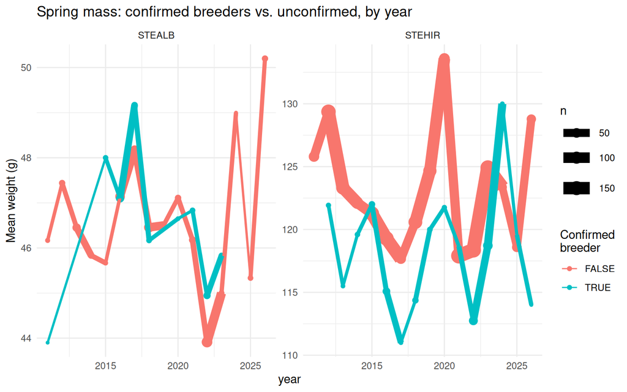

```r
ggplot(confirmed_by_year, aes(year, mean_weight, color = confirmed_breeder, size = n)) +
  geom_point() + geom_line(aes(group = confirmed_breeder)) +
  facet_wrap(~Species, scales = "free_y") +
  labs(title = "Spring mass: confirmed breeders vs. unconfirmed, by year",
       y = "Mean weight (g)", color = "Confirmed\nbreeder") +
  theme_minimal()
```

## 5.1 Significance tests

Two comparisons. Note “confirmed breeders” is no longer a strict subset of task 1’s “all spring individuals” cohort - task 1 is `is_new`-only (that’s how it reproduces Yosef’s `hirMASS`/`albMASS`), while confirmed breeders here can include recaptured adults too. So (a) compares confirmed breeders against Yosef’s original spring parameter as defined, and (b) is the cleaner apples-to-apples split within the broader (new+recapture) spring adult cohort built here:

**(a) Confirmed breeders vs. Yosef’s original spring parameter** (task 1’s `is_new`-only cohort, as originally computed - checks whether the breeder-confirmed subset differs from the parameter as Yosef defined it):

```r
for (sp in c("STEHIR", "STEALB")) {
  confirmed_w <- spring_adults %>% filter(Species == sp, confirmed_breeder) %>% pull(Weight)
  all_spring_w <- spring_records %>% filter(Species == sp) %>% pull(Weight)
  tt <- t.test(confirmed_w, all_spring_w)
  cat("**", sp, "**: confirmed n=", length(confirmed_w), ", mean=", round(mean(confirmed_w), 2),
      "g; all-spring n=", length(all_spring_w), ", mean=", round(mean(all_spring_w), 2),
      "g; Welch t-test p=", signif(tt$p.value, 3), "\n\n", sep = "")
}
```

**STEHIR**: confirmed n=180, mean=117.13g; all-spring n=1828, mean=122.36g; Welch t-test p=3.48e-12

**STEALB**: confirmed n=86, mean=46.77g; all-spring n=309, mean=46.5g; Welch t-test p=0.623

**(b) Confirmed vs. unconfirmed spring adults** (non-overlapping groups - the cleaner comparison, isolating “stayed” vs. “didn’t stay” among adults):

```r
for (sp in c("STEHIR", "STEALB")) {
  confirmed_w <- spring_adults %>% filter(Species == sp, confirmed_breeder) %>% pull(Weight)
  unconfirmed_w <- spring_adults %>% filter(Species == sp, !confirmed_breeder) %>% pull(Weight)
  tt <- t.test(confirmed_w, unconfirmed_w)
  wt <- wilcox.test(confirmed_w, unconfirmed_w)
  cat("**", sp, "**: confirmed n=", length(confirmed_w), ", mean=", round(mean(confirmed_w), 2),
      "g; unconfirmed n=", length(unconfirmed_w), ", mean=", round(mean(unconfirmed_w), 2),
      "g; Welch t-test p=", signif(tt$p.value, 3),
      ", Wilcoxon p=", signif(wt$p.value, 3), "\n\n", sep = "")
}
```

**STEHIR**: confirmed n=180, mean=117.13g; unconfirmed n=1903, mean=122.53g; Welch t-test p=8.18e-13, Wilcoxon p=5.7e-12

**STEALB**: confirmed n=86, mean=46.77g; unconfirmed n=322, mean=46.24g; Welch t-test p=0.32, Wilcoxon p=0.529

**(c) Year-controlled robustness check.** Both groups’ weights vary by year, which could confound a naive pooled comparison if “confirmed” records happen to cluster in heavier- or lighter-than-average years. This model estimates the confirmed-breeder effect while holding year fixed:

```r
for (sp in c("STEHIR", "STEALB")) {
  d <- spring_adults %>% filter(Species == sp) %>% mutate(year = factor(year))
  m <- lm(Weight ~ confirmed_breeder + year, data = d)
  co <- summary(m)$coefficients
  row <- co[grepl("confirmed_breeder", rownames(co)), , drop = FALSE]
  cat("**", sp, "** (year-controlled): confirmed-breeder effect = ",
      round(row[1, "Estimate"], 2), " g (SE ", round(row[1, "Std. Error"], 2),
      "), p = ", signif(row[1, "Pr(>|t|)"], 3), "\n\n", sep = "")
}
```

**STEHIR** (year-controlled): confirmed-breeder effect = -4.45 g (SE 0.8), p = 3.09e-08

**STEALB** (year-controlled): confirmed-breeder effect = 0.48 g (SE 0.49), p = 0.327

## 5.2 Interpretation

Read the three tests together per species rather than any single p-value: (a) and (b) tell you the raw pooled-across-years difference; (c) tells you whether that difference survives once year-to-year variation is accounted for. Small per-year sample sizes (see the per-year table above) mean this should be treated as an exploratory signal, not a final result, until Yosef/Inbal review sample sizes per group per year.

# 6 Task 2c: Confirmed-breeder spring mass - any-year site fidelity

**This is the chosen definition for downstream analysis** (decided 2026-09-08, after comparing both side by side - see the 2b vs. 2c comparison table at the end of this section). Task 2b (same-year) is kept above for reference/transparency, not deleted.

```r
summer_ring_ids_anyyear <- terns %>%
  filter(month %in% 6:7) %>%
  distinct(ring_id) %>%
  pull(ring_id)

spring_adults_anyyear <- spring_adults %>%
  mutate(confirmed_breeder_anyyear = ring_id %in% summer_ring_ids_anyyear)

kable(spring_adults_anyyear %>% count(Species, confirmed_breeder_anyyear),
      caption = "Spring adults: confirmed via a summer sighting in ANY year vs. never recorded in summer")
```

Spring adults: confirmed via a summer sighting in ANY year vs. never recorded in summer

| Species | confirmed_breeder_anyyear | n |
| --- | --- | --- |
| STEALB | FALSE | 224 |
| STEALB | TRUE | 184 |
| STEHIR | FALSE | 1593 |
| STEHIR | TRUE | 490 |

```r
confirmed_summary_anyyear <- spring_adults_anyyear %>%
  group_by(Species, confirmed_breeder_anyyear) %>%
  summarise(mean_weight = mean(Weight), sd_weight = sd(Weight), n = n(), .groups = "drop")

kable(confirmed_summary_anyyear, digits = 2,
      caption = "Spring weight: any-year confirmed breeders vs. never recorded in summer")
```

Spring weight: any-year confirmed breeders vs. never recorded in summer

| Species | confirmed_breeder_anyyear | mean_weight | sd_weight | n |
| --- | --- | --- | --- | --- |
| STEALB | FALSE | 46.44 | 3.92 | 224 |
| STEALB | TRUE | 46.24 | 3.97 | 184 |
| STEHIR | FALSE | 123.10 | 10.78 | 1593 |
| STEHIR | TRUE | 118.68 | 10.34 | 490 |

```r
confirmed_by_year_anyyear <- spring_adults_anyyear %>%
  group_by(year, Species, confirmed_breeder_anyyear) %>%
  summarise(mean_weight = mean(Weight), n = n(), .groups = "drop")

kable(confirmed_by_year_anyyear, digits = 2)
```

| year | Species | confirmed_breeder_anyyear | mean_weight | n |
| --- | --- | --- | --- | --- |
| 2011 | STEALB | FALSE | 46.70 | 1 |
| 2011 | STEALB | TRUE | 45.23 | 3 |
| 2011 | STEHIR | FALSE | 125.70 | 54 |
| 2011 | STEHIR | TRUE | 126.26 | 12 |
| 2012 | STEALB | FALSE | 47.96 | 9 |
| 2012 | STEALB | TRUE | 42.80 | 1 |
| 2012 | STEHIR | FALSE | 129.27 | 127 |
| 2012 | STEHIR | TRUE | 128.95 | 42 |
| 2013 | STEALB | FALSE | 46.29 | 21 |
| 2013 | STEALB | TRUE | 46.80 | 10 |
| 2013 | STEHIR | FALSE | 123.88 | 128 |
| 2013 | STEHIR | TRUE | 117.00 | 14 |
| 2014 | STEALB | FALSE | 45.56 | 9 |
| 2014 | STEALB | TRUE | 46.67 | 3 |
| 2014 | STEHIR | FALSE | 122.72 | 76 |
| 2014 | STEHIR | TRUE | 119.62 | 24 |
| 2015 | STEALB | FALSE | 45.50 | 2 |
| 2015 | STEALB | TRUE | 47.67 | 6 |
| 2015 | STEHIR | FALSE | 121.58 | 133 |
| 2015 | STEHIR | TRUE | 120.44 | 39 |
| 2016 | STEALB | FALSE | 47.27 | 37 |
| 2016 | STEALB | TRUE | 47.00 | 43 |
| 2016 | STEHIR | FALSE | 119.84 | 120 |
| 2016 | STEHIR | TRUE | 116.96 | 70 |
| 2017 | STEALB | FALSE | 47.95 | 20 |
| 2017 | STEALB | TRUE | 49.05 | 19 |
| 2017 | STEHIR | FALSE | 117.61 | 51 |
| 2017 | STEHIR | TRUE | 116.73 | 11 |
| 2018 | STEALB | FALSE | 46.71 | 48 |
| 2018 | STEALB | TRUE | 45.53 | 15 |
| 2018 | STEHIR | FALSE | 121.67 | 122 |
| 2018 | STEHIR | TRUE | 114.68 | 34 |
| 2019 | STEALB | FALSE | 46.50 | 6 |
| 2019 | STEALB | TRUE | 46.50 | 2 |
| 2019 | STEHIR | FALSE | 125.88 | 113 |
| 2019 | STEHIR | TRUE | 117.18 | 22 |
| 2020 | STEALB | FALSE | 46.50 | 7 |
| 2020 | STEALB | TRUE | 47.67 | 6 |
| 2020 | STEHIR | FALSE | 135.89 | 53 |
| 2020 | STEHIR | TRUE | 126.26 | 23 |
| 2021 | STEALB | FALSE | 46.14 | 7 |
| 2021 | STEALB | TRUE | 46.44 | 16 |
| 2021 | STEHIR | FALSE | 118.53 | 158 |
| 2021 | STEHIR | TRUE | 116.23 | 53 |
| 2022 | STEALB | FALSE | 43.92 | 36 |
| 2022 | STEALB | TRUE | 44.27 | 51 |
| 2022 | STEHIR | FALSE | 118.99 | 175 |
| 2022 | STEHIR | TRUE | 112.30 | 54 |
| 2023 | STEALB | FALSE | 44.83 | 6 |
| 2023 | STEALB | TRUE | 45.86 | 7 |
| 2023 | STEHIR | FALSE | 125.69 | 159 |
| 2023 | STEHIR | TRUE | 118.46 | 67 |
| 2024 | STEALB | FALSE | 49.00 | 1 |
| 2024 | STEHIR | FALSE | 123.93 | 41 |
| 2024 | STEHIR | TRUE | 120.00 | 3 |
| 2025 | STEALB | FALSE | 45.33 | 6 |
| 2025 | STEHIR | FALSE | 119.29 | 45 |
| 2025 | STEHIR | TRUE | 116.69 | 13 |
| 2026 | STEALB | FALSE | 50.38 | 8 |
| 2026 | STEALB | TRUE | 49.50 | 2 |
| 2026 | STEHIR | FALSE | 129.24 | 38 |
| 2026 | STEHIR | TRUE | 125.22 | 9 |

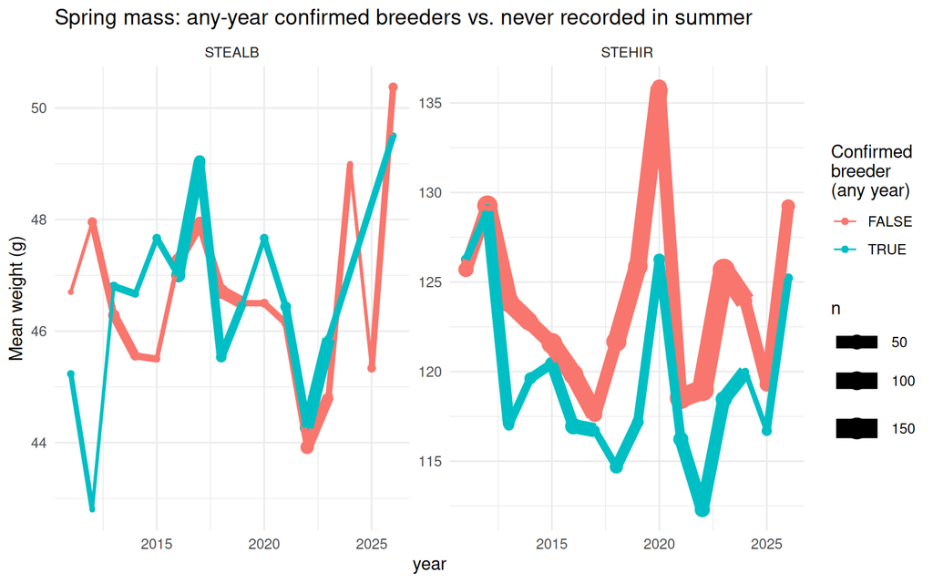

```r
ggplot(confirmed_by_year_anyyear, aes(year, mean_weight, color = confirmed_breeder_anyyear, size = n)) +
  geom_point() + geom_line(aes(group = confirmed_breeder_anyyear)) +
  facet_wrap(~Species, scales = "free_y") +
  labs(title = "Spring mass: any-year confirmed breeders vs. never recorded in summer",
       y = "Mean weight (g)", color = "Confirmed\nbreeder\n(any year)") +
  theme_minimal()
```

## 6.1 Significance tests (any-year version)

Same three-test structure as task 2b, substituting the any-year flag:

```r
for (sp in c("STEHIR", "STEALB")) {
  confirmed_w <- spring_adults_anyyear %>% filter(Species == sp, confirmed_breeder_anyyear) %>% pull(Weight)
  all_spring_w <- spring_records %>% filter(Species == sp) %>% pull(Weight)
  tt <- t.test(confirmed_w, all_spring_w)
  cat("**", sp, "**: confirmed (any-year) n=", length(confirmed_w), ", mean=", round(mean(confirmed_w), 2),
      "g; all-spring (Yosef's parameter) n=", length(all_spring_w), ", mean=", round(mean(all_spring_w), 2),
      "g; Welch t-test p=", signif(tt$p.value, 3), "\n\n", sep = "")
}
```

**STEHIR**: confirmed (any-year) n=490, mean=118.68g; all-spring (Yosef’s parameter) n=1828, mean=122.36g; Welch t-test p=7.65e-12

**STEALB**: confirmed (any-year) n=184, mean=46.24g; all-spring (Yosef’s parameter) n=309, mean=46.5g; Welch t-test p=0.481

```r
for (sp in c("STEHIR", "STEALB")) {
  confirmed_w <- spring_adults_anyyear %>% filter(Species == sp, confirmed_breeder_anyyear) %>% pull(Weight)
  unconfirmed_w <- spring_adults_anyyear %>% filter(Species == sp, !confirmed_breeder_anyyear) %>% pull(Weight)
  tt <- t.test(confirmed_w, unconfirmed_w)
  wt <- wilcox.test(confirmed_w, unconfirmed_w)
  cat("**", sp, "**: confirmed (any-year) n=", length(confirmed_w), ", mean=", round(mean(confirmed_w), 2),
      "g; never-seen-in-summer n=", length(unconfirmed_w), ", mean=", round(mean(unconfirmed_w), 2),
      "g; Welch t-test p=", signif(tt$p.value, 3),
      ", Wilcoxon p=", signif(wt$p.value, 3), "\n\n", sep = "")
}
```

**STEHIR**: confirmed (any-year) n=490, mean=118.68g; never-seen-in-summer n=1593, mean=123.1g; Welch t-test p=9.06e-16, Wilcoxon p=3.4e-17

**STEALB**: confirmed (any-year) n=184, mean=46.24g; never-seen-in-summer n=224, mean=46.44g; Welch t-test p=0.612, Wilcoxon p=0.474

```r
for (sp in c("STEHIR", "STEALB")) {
  d <- spring_adults_anyyear %>% filter(Species == sp) %>% mutate(year = factor(year))
  m <- lm(Weight ~ confirmed_breeder_anyyear + year, data = d)
  co <- summary(m)$coefficients
  row <- co[grepl("confirmed_breeder_anyyear", rownames(co)), , drop = FALSE]
  cat("**", sp, "** (year-controlled): confirmed-breeder(any-year) effect = ",
      round(row[1, "Estimate"], 2), " g (SE ", round(row[1, "Std. Error"], 2),
      "), p = ", signif(row[1, "Pr(>|t|)"], 3), "\n\n", sep = "")
}
```

**STEHIR** (year-controlled): confirmed-breeder(any-year) effect = -4.37 g (SE 0.52), p = 6.44e-17

**STEALB** (year-controlled): confirmed-breeder(any-year) effect = 0.11 g (SE 0.4), p = 0.774

## 6.2 Same-year (2b) vs. any-year (2c) comparison

```r
compare_2b_2c <- bind_rows(
  spring_adults %>% mutate(definition = "same-year (2b)") %>% rename(confirmed = confirmed_breeder),
  spring_adults_anyyear %>% mutate(definition = "any-year (2c)") %>% rename(confirmed = confirmed_breeder_anyyear)
) %>%
  filter(confirmed) %>%
  group_by(Species, definition) %>%
  summarise(mean_weight = mean(Weight), sd_weight = sd(Weight), n = n(), .groups = "drop")

kable(compare_2b_2c, digits = 2, caption = "Confirmed-breeder group only: same-year vs. any-year definition")
```

Confirmed-breeder group only: same-year vs. any-year definition

| Species | definition | mean_weight | sd_weight | n |
| --- | --- | --- | --- | --- |
| STEALB | any-year (2c) | 46.24 | 3.97 | 184 |
| STEALB | same-year (2b) | 46.77 | 4.53 | 86 |
| STEHIR | any-year (2c) | 118.68 | 10.34 | 490 |
| STEHIR | same-year (2b) | 117.13 | 8.96 | 180 |

# 7 Save outputs

```r
write.csv(spring_mass, file.path(proc_dir, "spring_mass_by_year_species.csv"), row.names = FALSE)
write.csv(breeding_mass, file.path(proc_dir, "breeding_mass_by_year_species.csv"), row.names = FALSE)
write.csv(
  spring_adults_anyyear %>%
    select(ring_id, year, Species, Age, Weight, is_new, confirmed_breeder, confirmed_breeder_anyyear),
  file.path(proc_dir, "confirmed_breeder_spring_mass.csv"),
  row.names = FALSE
)

# ---- Update master_dataset_2010_2026.csv's hirMASS/albMASS columns -----
# Spring metric remains the single source for hirMASS/albMASS across all
# years (2011-2026), as established in the prior session - superseding
# data1.csv's 2012-2020-only values.
mass_wide <- spring_mass %>%
  mutate(col = ifelse(Species == "STEHIR", "hirMASS_new", "albMASS_new"),
         mean_weight = round(mean_weight, 1)) %>%
  select(year, col, mean_weight) %>%
  pivot_wider(names_from = col, values_from = mean_weight)

master_path <- file.path(proc_dir, "master_dataset_2010_2026.csv")
master <- read.csv(master_path) %>%
  select(-hirMASS, -albMASS) %>%
  left_join(mass_wide, by = "year") %>%
  rename(hirMASS = hirMASS_new, albMASS = albMASS_new)

write.csv(master, master_path, row.names = FALSE, na = "NA")
cat("Updated", master_path, "and wrote 3 CSVs to", proc_dir, "\n")
```

```
## Updated ../data_processed/master_dataset_2010_2026.csv and wrote 3 CSVs to ../data_processed
```